# Softver R moje poznamky uvod do prace v R - Grafika v R

Dominik Zatkalik, citovane materialy Tomas Bacigal

dnes

Uvod do R ka je v nadradenej stranke r.htm

# Uvod

cite Tomas Bacigal:

# Grafika v R

## Staticke obazky

### Zakladna grafika

```r
data_wide <- matrix(c(10, 7, 12, 9, 11, 6), nrow = 2, ncol = 3, byrow = T, dimnames = list(paste0("B",1:2), paste0("A", 1:3))
                    )
```

data vo wide formate

```r
data_wide
```

```
##    A1 A2 A3
## B1 10  7 12
## B2  9 11  6
```

co robi toto??? rozdeli grafiku na 2 stlpce aby mohli byt 2 grafy v jednom riadku

```r
par(mfrow=c(1,2))
```

2 sposoby vykrslenia dat

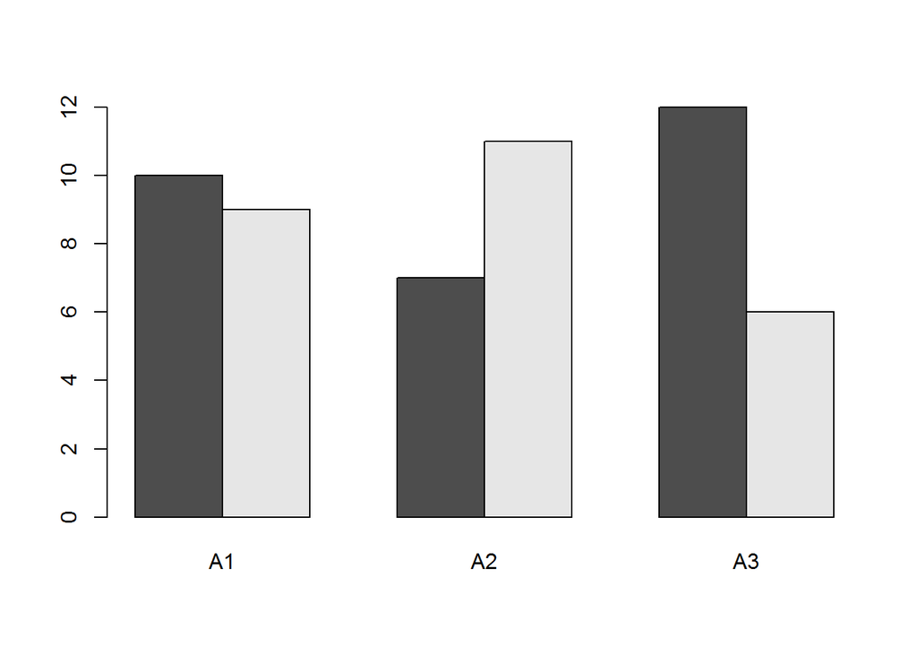

```r
barplot(data_wide, beside = TRUE)
```

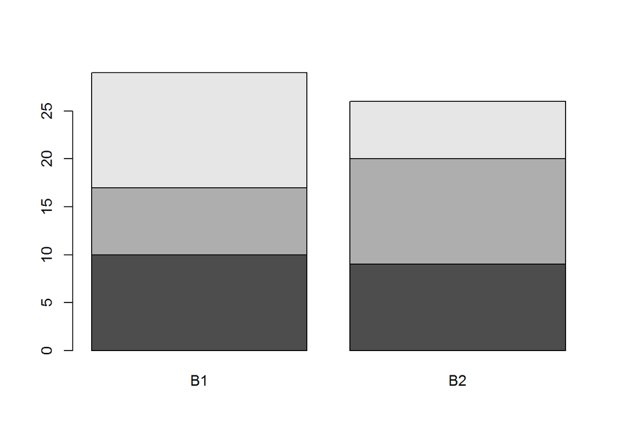

```r
barplot(t(data_wide), beside = FALSE)
```

nastavenie oblasti pre grafiky spat na jeden graf v riadku

```r
par(mfrow=c(1,1))
```

iny typ grafu

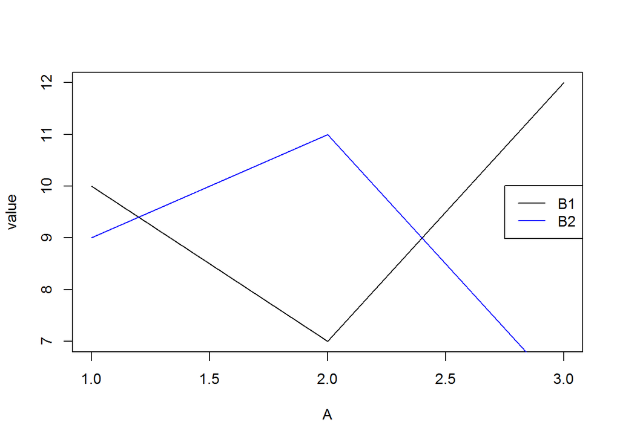

```r
plot(data_wide[1,], type="l", xlab = "A", ylab = "value")
lines(data_wide[2,], type="l", col="blue")
legend("right", legend = rownames(data_wide), lty = c(1,1),col=c("black","blue"))
```

Pomockou pre vizualizaciu pomocou zakladnej grafiky R je napr. balik GrapheR - uzivatelske prostredie s mnozstvom volieb pre tvorbu 6 druhov grafov: histogram, box-and-whisker plot, bar plot, pie chart, curve and scatter plot.  
https://journal.r-project.org/archive/2011-2/RJournal_2011-2_Herve.pdf

```r
library(GrapheR)
```

??? asi nejake data

```r
data("iris")
```

natiahne data iris do premennych

```r
run.GrapheR()
```

```
## <Tcl>
```

Altrernativou je zobrazenie pomocou nastrojov baliku ggplot2, ktore produkuju ovela “vyladenejsie” a na pohlad krajsie grafy. Dobry uvod a tipy pre ggplot2: Chang2013-R_Graphics_Cookbook  
Data treba pripravit v tzv. long formate.

```r
data_long <- reshape2::melt(data_wide, varnames=c("Bval","Aval"), value.name="value")

library(ggplot2)
```

Grafy pomocou ggplot2, komponenty grafu sa pridavaju pomocou “+”

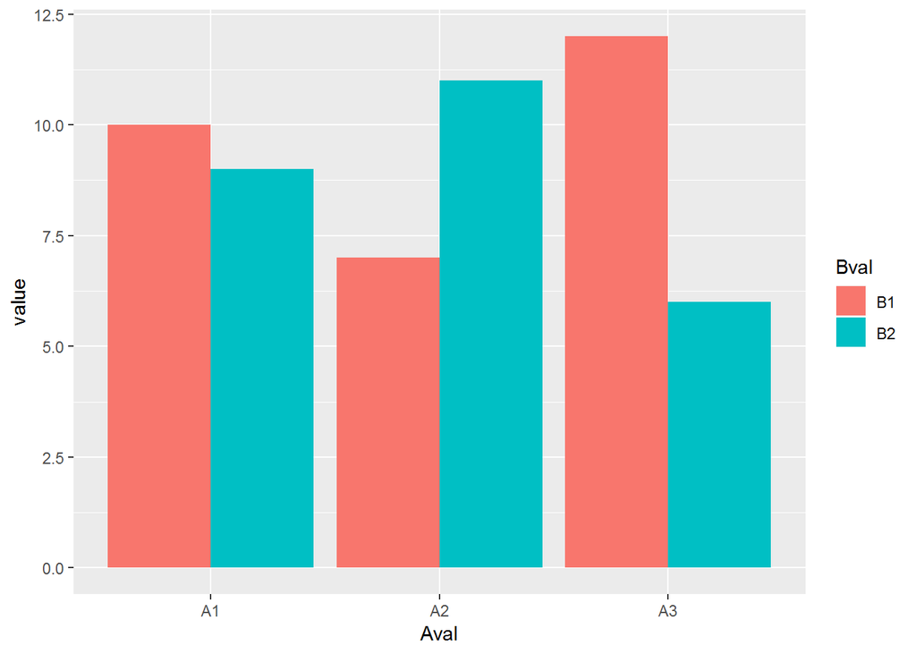

```r
ggplot(data_long, aes(x=Aval, y=value, fill=Bval)) + geom_bar(stat="identity", position="dodge")
```

vyhoda je ze nie je nutne vopred transponovat ani inak trnasformovt data

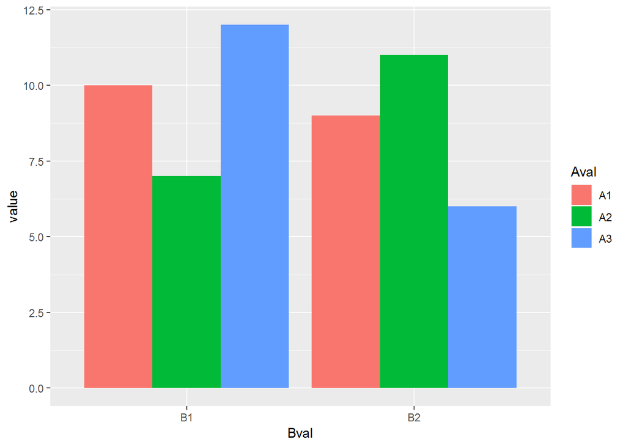

```r
ggplot(data_long, aes(x=Bval, y=value, fill=Aval)) + geom_bar(stat = "identity", position = "dodge")
```

typ grafu sa urci komponenetom zodpovednym za geometriu

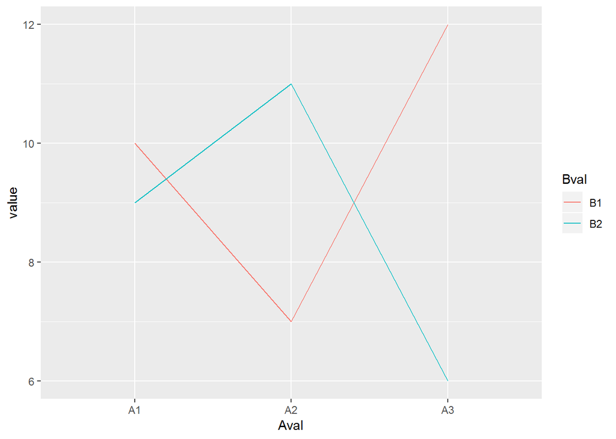

```r
ggplot(data_long, aes(x=Aval, y=value, colour=Bval, group=Bval)) + geom_line()
```

dalsou vyhodou je, ze graf je prisposobeny rozsahu vsetkych dat, na rozdiel od pridavania vrstiev klasickym sposobom cez lines, points a pod. ggplot2 pouziva nasledovnu terminologiu:

```r
#  * data - v stlpcoch obsahuje premenne, ktorych hodnoty chceme zobrazit, najma numericke, kategorialne a znakove
#  * geom - geometricke objekty, ktore reprezentuju udaje, napr. stlpce, krivky, body
#  * aes - aesthetics, esteticke (vizualne) vlastnosti geometrickych udajov, napr. poloha, farba a hrubka ciar, tvar a velkost bodovych znaciek
#  * scale - uprava zobrazenia ("mapping") z priestoru udajov do priestoru vizualnych vlastnosti (aes), napr. spojita miera na osi y zobrazuje vacsie numericke hodnoty do vyssej polohy v priestore
#  * guide - ukazuje ako interpretovat/premietnut vizualne vlastnosti naspat do priestoru udajov, napr. ciarky na osi, popis osi, legenda
```

dalsia ukazka

```r
( data <- data.frame(xval=1:4, yval=c(3,5,6,9), group=c("A","B","A","B")))
```

```
##   xval yval group
## 1    1    3     A
## 2    2    5     B
## 3    3    6     A
## 4    4    9     B
```

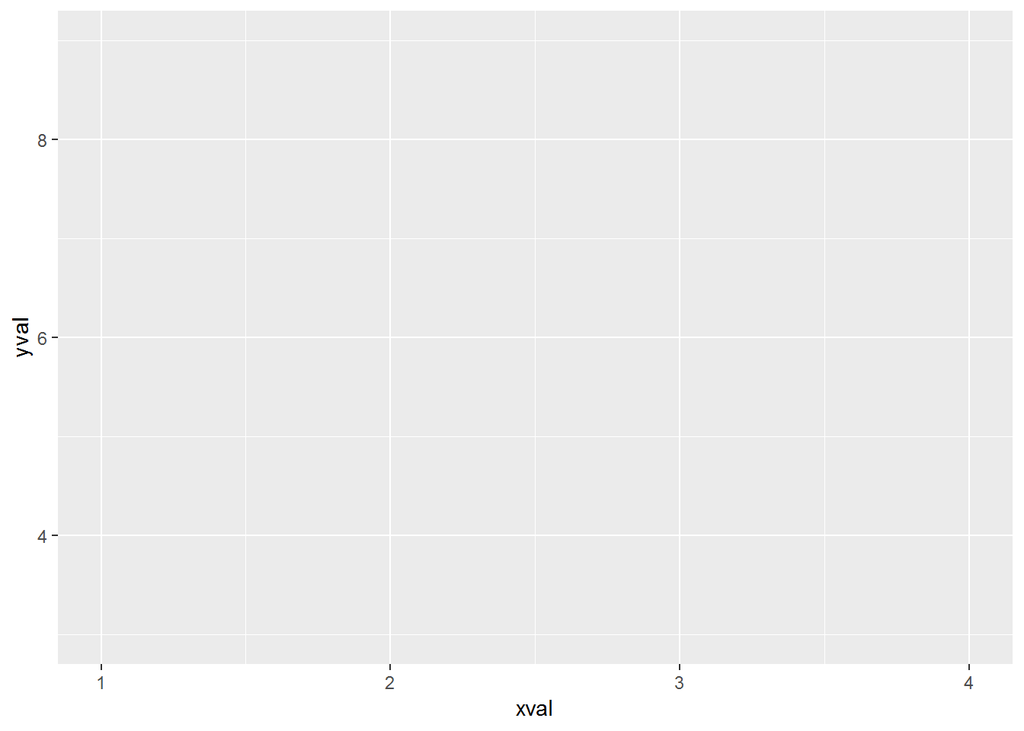

```r
ggplot(data, aes(x=xval, y=yval))
```

ulozime do premennej a budeme pridavat geometricke komponenty

```r
p <- ggplot(data, aes(x=xval, y=yval))
```

s bodkami

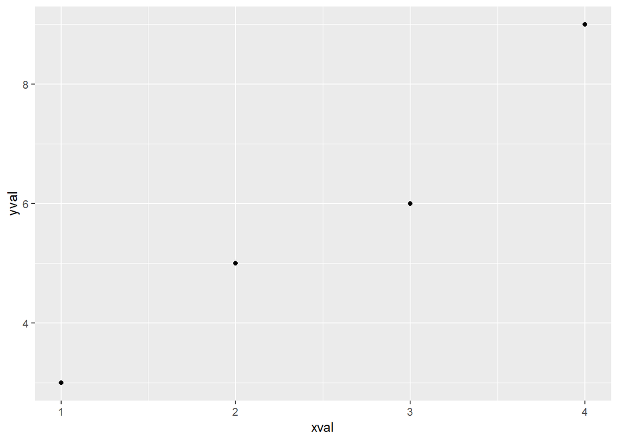

```r
p + geom_point()
```

aesthetic mapping

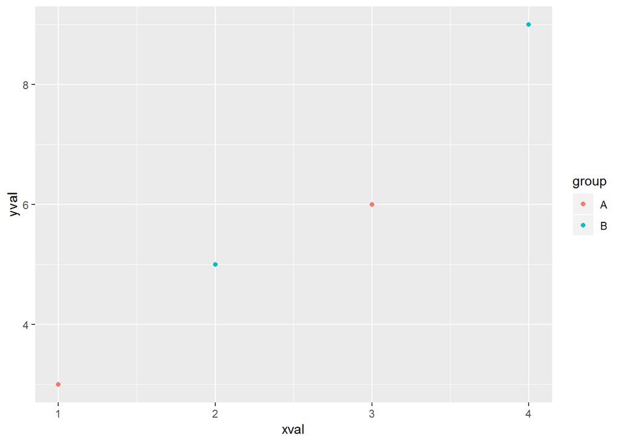

```r
p + geom_point(aes(colour=group))
```

aesthetic setting

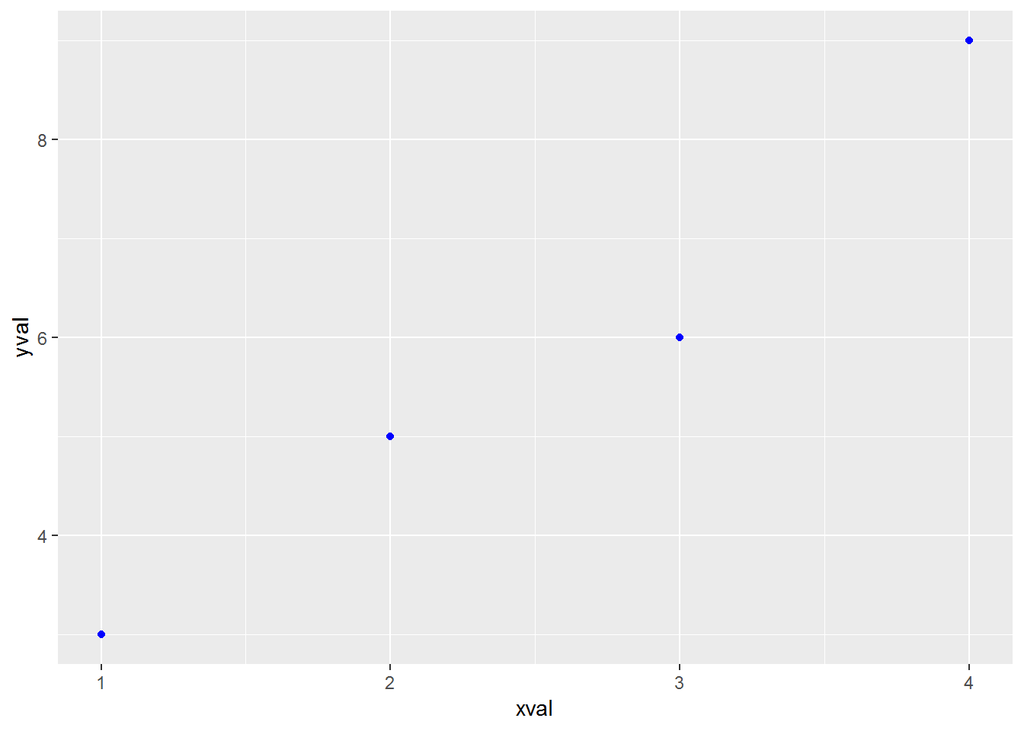

```r
p + geom_point(colour="blue")
```

scale

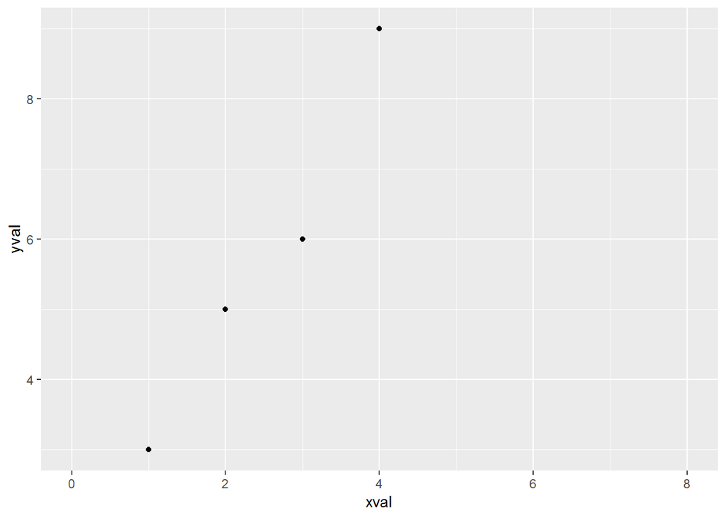

```r
p + geom_point() + scale_x_continuous(limits=c(0,8))
```

zmeni aj legendu

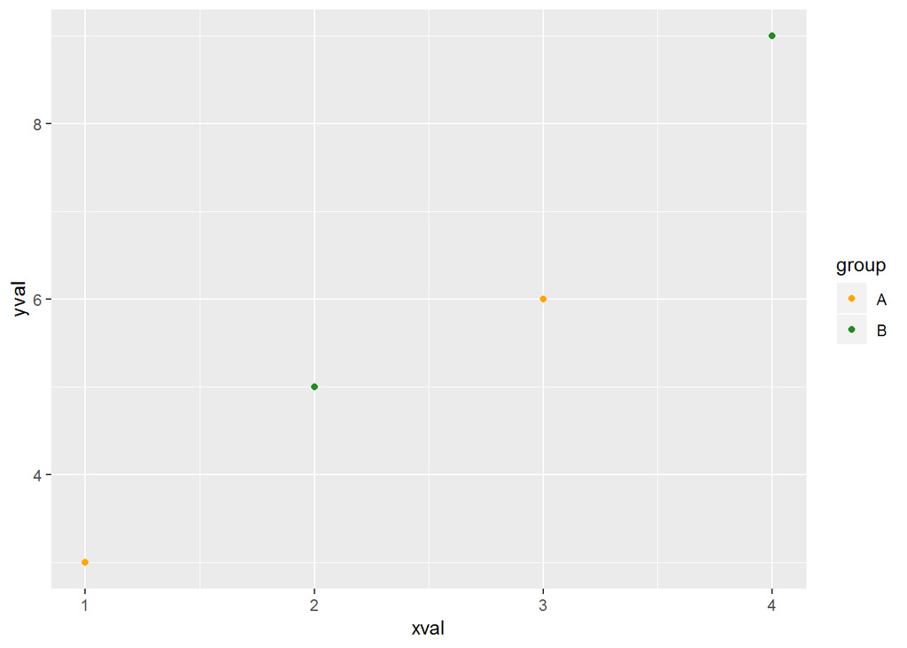

```r
p + geom_point(aes(colour=group)) + scale_colour_manual(values=c("orange", "forestgreen"))
```

## Interaktivne grafy

### identify() & locator()

najjednoduchsi nastroj poskytuje identify() a locator() scaterplot

```r
#plot(data$x, data$y)
```

treba kurzorom zvolit body, potom Esc

```r
#identity(data$x, data$y, labels=row.names(data))
#coords <- locator(type="l") # zvlolene body budu pospajane ciarou
#coords # list suradnic x a y
```

### manipulate

jednoduche priklady s manipulate: https://support.rstudio.com/hc/en-us/articles/200551906-Interactive-Plotting-with-Manipulate

```r
library(manipulate)
```

interaktivne prvky pod ozubenym kolieckom FUNGUJE LEN V RKU NEJDE KOMPILOVAT DO REPORTU

```r
#manipulate(
#  plot(cars, xlim= c(0, x.max), type=type, ann= label),
#  x.max = slider(10, 25, step=5, initial=25),
#  type = picker("Points" = "p", "Line" = "l", "Step" = "s"),
#  label = checkbox(TRUE, "Draw Labels")
#)
```

### ggvis

Balik stavajuci na logike “grammar of graphics” (podobne ako ggplot2).  
Zdroj: http://ggvis.rstudio.com/ggvis-basics.html

```r
library(ggvis)
```

balik dat technickej specifikacie vybranych automobilov

```r
data(mtcars)
```

staticke grafy ggvis

```r
p <- ggvis(mtcars, x=~wt, y= ~mpg) # hmotnost wt vs dojazd na galon paliva mpg
layer_points(p)
```

alternativny postup

```r
mtcars %>% # pipe operator (pouziva ho pomerne vela balikov, original v "magrittr")
  ggvis(x = ~wt, y = ~mpg) %>%  # ~ indikuje pouzitie lokalnej premennej z datoveho ramca mtcars
  layer_points()
```

```r
library(dplyr)
mtcars %>%
  ggvis(x = ~mpg, y = ~disp) %>%
  mutate(disp = disp / 61.0237) %>% # konvertuj zdvihovy objem (displacement) z kubickych palcov na litre
  layer_points()
```

```r
mtcars %>% ggvis(~mpg, ~disp, fill = ~vs) %>% layer_points()  #okrem fill mozno pouzit stroke, size alebo shape:
```

```r
mtcars %>% ggvis(~mpg, ~disp, shape = ~factor(cyl)) %>% layer_points()
```

```r
mtcars %>% ggvis(~wt, ~mpg, size := 300, opacity := 0.4) %>% layer_points()  # zadanie fixnej hodnoty musi ist cez operator ":="
```

interaktivne grafy ggvis

```r
mtcars %>%
  ggvis(~wt, ~mpg, size := input_slider(10,100), opacity:= input_slider(0,1)) %>%
layer_points()
```

```r
mtcars %>%
  ggvis(~wt) %>%
  layer_histograms(width =  input_slider(0, 2, step = 0.10, label = "width"),
                   center = input_slider(0, 2, step = 0.05, label = "center"))
keys_s <- left_right(10, 1000, step = 50)
mtcars %>% ggvis(~wt, ~mpg, size := keys_s, opacity := 0.5) %>% layer_points()  # velkost kontrolovana sipkami
mtcars %>% ggvis(~wt, ~mpg) %>%
  layer_points() %>%
  add_tooltip(function(df) df$wt)
```

### ggobi

(http://www.ggobi.org/rggobi/introduction.pdf)

### scatterD3

‘D3’ ‘JavaScript’ scatterplots from ‘R’ with interactive features : panning, zooming, tooltips, etc.  
Zdroj: https://cran.r-project.org/web/packages/scatterD3/vignettes/introduction.html

```r
library(scatterD3)
```

zakladny skaterplot graf je mozne priblizovat a oddialovat

```r
scatterD3(x = wt, y = mpg, data = mtcars)
```

[interactive chart not shown]

graf je mozne priblizovat a oddialovat os y nula

```r
scatterD3(data = mtcars, x = wt, y = mpg, point_size = 35, point_opacity = 0.5, fixed = TRUE)
```

[interactive chart not shown]

kategoricke premenne

```r
mtcars$cyl_fac <- paste(mtcars$cyl, "cylinders")
scatterD3(data = mtcars, x = cyl_fac, y=mpg)
```

[interactive chart not shown]

popisy bodov

```r
mtcars$names <- rownames(mtcars)
scatterD3(data = mtcars, x=wt, y = mpg, lab=names, labels_size = 9)
```

[interactive chart not shown]

dalsie parametre

```r
scatterD3(data = mtcars, x = wt, y = mpg, col_var = cyl, symbol_var = gear)
```

[interactive chart not shown]

```r
scatterD3(data = mtcars, x = wt, y = mpg, col_var = cyl, size_var = hp,
          size_range = c(10,1000), point_opacity = 0.7)
```

[interactive chart not shown]

```r
scatterD3(data = mtcars, x = wt, y = mpg, col_var = cyl,
          colors = c("4" = "#ECD078", "8" = "#C02942", "6" = "#53777A"))
```

[interactive chart not shown]

```r
scatterD3(data = mtcars, x = wt, y = mpg, col_var = disp)
```

[interactive chart not shown]

pridanie ciary

```r
lm(mpg ~ wt, mtcars)
```

```
##
## Call:
## lm(formula = mpg ~ wt, data = mtcars)
##
## Coefficients:
## (Intercept)           wt
##      37.285       -5.344
```

```r
scatterD3(data = mtcars, x = wt, y = mpg, lines = data.frame(slope = -5.344, intercept = 37.285))
```

[interactive chart not shown]

uprava popisu aktivuje sa nechanim kurzora na modrom bode zobrazi text

```r
tooltips <- paste("This is an incredible <strong>", rownames(mtcars), "</strong> <br /> with", mtcars$cyl, "cylinders !")
scatterD3(data = mtcars, x=wt, y = mpg, tooltip_text = tooltips)
```

[interactive chart not shown]

elipsy spolahlivosti okolo bodov

```r
scatterD3(data = mtcars, x=wt, y = mpg, col_var = cyl, ellipses = TRUE)
```

[interactive chart not shown]

vyber lasom

```r
mtcars$names <- rownames(mtcars)
scatterD3(data = mtcars, x=wt, y = mpg, lab = names, lasso = TRUE) # Shift + LMB
```

[interactive chart not shown]

Funkcii je ovela viac, treba pozriet manual… ### ggraptR

Nastroj na interaktivnu pracu s datami

Rapid And Pretty Things in R: A shiny GUI for Data Visualisation and Analysis with ggplot2  
Intended for both technical and non-technical users to create interactive data visualizations through a web browser GUI without writing any code.  
Vignette: https://cran.r-project.org/web/packages/ggraptR/vignettes/ggraptR.html

```r
ggraptR::ggraptR(mtcars)
```

```
##
## Listening on http://127.0.0.1:6012
```

# Prezentacia analyz

zdroj: R for Data Science (Garrett Grolemund, Hadley Wickham) http://r4ds.had.co.nz/

R Markdown provides a unified authoring framework for data science, combining your code, its results, and your prose commentary. R Markdown documents are fully reproducible and support dozens of output formats, like PDFs, Word files, slideshows, and more.  
R Markdown files are designed to be used in three ways:  
* For communicating to decision makers, who want to focus on the conclusions, not the code behind the analysis. * For collaborating with other data scientists (including future you!), who are interested in both your conclusions, and how you reached them (i.e., the code). * As an environment in which to do data science, as a modern day lab notebook where you can capture not only what you did, but also what you were thinking.

R Markdown formats: * Documents (pdf, html, doc, rtf, md, github) * Notebooks - html documents with full source code (to comunicate with other data scientists) * Presentations (ioslides, slidy, beamer, revealjs, rmdshower) * Dashboards (to communicate large amounts of information visually and quickly) * interactivity (htmlwidgets - client-side using JavaScript; shiny - server-side with running R) * websites * bookdown, prettydoc, rticles …